# Homework-number-5

Nandini Sharma, Nitin Verma

November 18, 2016

# Introduction

When we initially discussed the central limit theorem and confidence intervals, we showed how we could use bootstrapping to estimate standard errors and confidence intervals around certain parameter values, like the mean. Using bootstrapping, we could also do the same for estimating standard errors and CIs around regression parameters, such as $\beta$ coefficients.

# Linear Regression

## Reading Data

```r
library(curl)
f <- curl("https://raw.githubusercontent.com/difiore/ADA2016/master/KamilarAndCooperData.csv")
d <- read.csv(f, header=TRUE, stringsAsFactors=TRUE)
head(d)
```

```
##               Scientific_Name          Family          Genus      Species
## 1 Allenopithecus_nigroviridis Cercopithecidae Allenopithecus nigroviridis
## 2         Allocebus_trichotis Cercopithecidae      Allocebus    trichotis
## 3           Alouatta_belzebul        Atelidae       Alouatta     belzebul
## 4             Alouatta_caraya        Atelidae       Alouatta       caraya
## 5            Alouatta_guariba        Atelidae       Alouatta      guariba
## 6           Alouatta_palliata        Atelidae       Alouatta     palliata
##   Brain_Size_Species_Mean Brain_Size_Female_Mean   Brain_size_Ref
## 1                   58.02                  53.70 Isler et al 2008
## 2                      NA                     NA
## 3                   52.84                  51.19 Isler et al 2008
## 4                   52.63                  47.80 Isler et al 2008
## 5                   51.70                  49.08 Isler et al 2008
## 6                   49.88                  48.04 Isler et al 2008
##   Body_mass_male_mean Body_mass_female_mean Mass_Dimorphism
```

[output cut: 69 more lines]

## Part 1 - Regression Model

**Using the “KamilarAndCooperData.csv” dataset, run a linear regression looking at log(HomeRange_km2) in relation to log(Body_mass_female_mean) and report your β coefficients (slope and intercept).**

```r
y <- log(d$HomeRange_km2)
x <- log(d$Body_mass_female_mean)

#Building the Model
m <- lm(data=d, y ~ x)
summary(m)
```

```
##
## Call:
## lm(formula = y ~ x, data = d)
##
## Residuals:
##     Min      1Q  Median      3Q     Max
## -3.3929 -0.9433 -0.0126  1.0944  3.6826
##
## Coefficients:
##             Estimate Std. Error t value Pr(>|t|)
## (Intercept) -9.44123    0.67293  -14.03   <2e-16 ***
## x            1.03643    0.08488   12.21   <2e-16 ***
## ---
## Signif. codes:  0 '***' 0.001 '**' 0.01 '*' 0.05 '.' 0.1 ' ' 1
##
## Residual standard error: 1.423 on 135 degrees of freedom
##   (76 observations deleted due to missingness)
## Multiple R-squared:  0.5248, Adjusted R-squared:  0.5213
## F-statistic: 149.1 on 1 and 135 DF,  p-value: < 2.2e-16
```

```r
#Extracting Beta Coefficients
beta0 <- m$coefficients[1]
beta1 <- m$coefficients[2]

beta0
```

```
## (Intercept)
##   -9.441231
```

```r
beta1
```

```
##        x
## 1.036432
```

## Part 2 - BootStrapping

**Then, use bootstrapping to sample from your data 1000 times with replacement, each time fitting the same model and calculating the same coefficients. This generates a sampling distribution for each β coefficient.**

```r
#Defining Sample Size
n <- nrow(d)

beta0s <- NULL
beta1s <- NULL

#Bootstrapping for Beta Coefficients
for (i in 1:1000) {
  ds <- d[sample(c(1:n), n, replace=TRUE), ]
  ys <- log(ds$HomeRange_km2)
  xs <- log(ds$Body_mass_female_mean)
  ms <- lm(data=ds, ys ~ xs)

  beta0s[i] <- ms$coefficients[1]
  beta1s[i] <- ms$coefficients[2]
}
```

# Bootstrapping SE&CI

**Estimate the standard error for each of your β coefficients as the standard deviation of the sampling distribution from your bootstrap and determine the 95% CI for each of your β coefficients based on the appropriate quantiles from your sampling distribution.**

```r
#Standard Error from Bootstrap
se.beta0s <- sd(beta0s)
se.beta1s <- sd(beta1s)
se.beta0s
```

```
## [1] 0.6209249
```

```r
se.beta1s
```

```
## [1] 0.07974241
```

```r
#critval.beta0s <- qt(0.975, df= length(beta0s) - 1)
#critval.beta1s <- qt(0.975, df= length(beta1s) - 1)

#CI.beta0s = mean(beta0s) + c(-1, 1) * critval.beta0s * se.beta0s
#CI.beta1s = mean(beta1s) + c(-1, 1) * critval.beta1s * se.beta1s

#Calculating Confidence Intervals
CI.beta0s = quantile(beta0s, c(0.025, 0.975))
CI.beta1s = quantile(beta1s, c(0.025, 0.975))

CI.beta0s
```

```
##       2.5%      97.5%
## -10.702455  -8.335517
```

```r
CI.beta1s
```

```
##      2.5%     97.5%
## 0.8921815 1.1992797
```

## Comparing SE

**How does the former compare to the SE estimated from your entire dataset using the formula for standard error implemented in lm()?**

The SEs we calculated from bootstrap for `beta0` (0.6209249) and `beta1` (0.0797424) compare very well to the figures generated by `lm()` i.e. (0.6729346, 0.0848771).

## Comparing CI

**How does the latter compare to the 95% CI estimated from your entire dataset?**

The CIs for the model `m` gotten via `lm()` can be calculated as follows:

```r
#CI.lm <- confint(m, m$coefficients[1], 0.95)
CI.lm <- confint(m, level = 0.95)
CI.lm
```

```
##                   2.5 %    97.5 %
## (Intercept) -10.7720889 -8.110374
## x             0.8685707  1.204292
```

And these CIs compare very well with those obtained from bootstrapped sampling distributions i.e. beta0 **(-10.7024546, -8.3355171)** and beta1 **(0.8921815, 1.1992797)**.

# Encapsulating Function

**Write a FUNCTION that takes as its arguments a dataframe, “d”, a linear model, “m” (as a character string, e.g., “logHR~logBM”), a user-defined confidence interval level, “conf.level” (with default = 0.95), and a number of bootstrap replicates, “n” (with default = 1000). Your function should return a dataframe that includes: beta coefficient names; beta coefficients, standard errors, and upper and lower CI limits for the linear model based on your entire dataset; and mean beta coefficient estimates, SEs, and CI limits for those coefficients based on your bootstrap.**

```r
betaCoeffAnalysis = function(d1, m1, conf.level = 0.95, n = 1000){
  #Error handling for invalid dataframe/model
  if (nrow(d1) == 0 || is.null(m1)) {
    cat("ERROR!")
    return(NULL)
  }
  #Error handling for invalid confidence level
  if (conf.level > 1 || conf.level < 0) {
    cat("ERROR!")
    return(NULL)
  }
  #Extracting response and predictor variables from model string
  y1 <- strsplit(m1, "~")[[1]][[1]] #response variable
  x1 <- strsplit(m1, "~")[[1]][[2]] #predictor variable

  y <- d1[, c(y1)]
  x <- d1[, c(x1)]

  #Preparing result dataframe
  rdf <- data.frame(row.names = c("method", "beta", "est.value", "SE", "CI.lower", "CI.upper"))

  #Building regression model
  m <- lm(y ~ x)
  out <- summary(m)

  # Extracting coefficients and standard error from model
  b0.lm <- out$coefficients[1,1]
  se.b0.lm <- out$coefficients[1,2]
  b1.lm <- out$coefficients[2,1]
  se.b1.lm <- out$coefficients[2,2]

 # alpha <- conf.level + (1 - conf.level)/2

  # Extracting confidence interval from model
  CI.lm <- confint(m, level=conf.level)

  b0.lm.lwr <- CI.lm[1,1]
  b0.lm.upr <- CI.lm[1,2]
  b1.lm.lwr <- CI.lm[2,1]
  b1.lm.upr <- CI.lm[2,2]

  #Binding a record of model estimates for beta0 to the result dataframe rdf
  newrecord <- data.frame(method="lm", beta="beta0", est.value=b0.lm, SE=se.b0.lm, CI.lower=b0.lm.lwr, CI.upper=b0.lm.upr)
  rdf <- rbind(rdf, newrecord)

  #Binding a record of model estimates for beta1 to the result dataframe rdf
  newrecord <- data.frame(method="lm", beta="beta1", est.value=b1.lm, SE=se.b1.lm, CI.lower=b1.lm.lwr, CI.upper=b1.lm.upr)
  rdf <- rbind(rdf, newrecord)

  #Bootstrapping beta0 and beta1 estimates
  beta0s <- NULL
  beta1s <- NULL

  #Defining sample size for bootstrapping
  sz <- nrow(d1)
  for (i in 1:n) {

    ds <- d[sample(c(1:sz), sz, replace=TRUE), ]
    ys <- ds[, c(y1)]
    xs <- ds[, c(x1)]
    ms <- lm(ys ~ xs)

    beta0s[i] <- ms$coefficients[1]
    beta1s[i] <- ms$coefficients[2]
  }
  # Bootstrapped Mean and standard error for beta 0 and beta 1
  b0.bs <- mean(beta0s)
  b1.bs <- mean(beta1s)
  se.b0.bs <- sd(beta0s)
  se.b1.bs <- sd(beta1s)

#  critval.b0 <- qt(alpha, df= length(beta0s) - 1)
#  critval.b1 <- qt(alpha, df= length(beta1s) - 1)

#  CI.b0 = b0.bs + c(-1, 1) * critval.b0 * se.b0.bs
#  CI.b1 = b1.bs + c(-1, 1) * critval.b1 * se.b1.bs

  #Bootrapping confidence interval

  CI.b0 <- quantile(beta0s, level = conf.level)
  CI.b1 <- quantile(beta1s, level = conf.level )

  b0.bs.lwr <- CI.b0[1]
  b0.bs.upr <- CI.b0[2]
  b1.bs.lwr <- CI.b1[1]
  b1.bs.upr <- CI.b1[2]

  #Binding a record of bootstrapped estimates for beta0 to the result dataframe rdf
  newrecord = data.frame(method="bootstrap", beta="beta0", est.value=b0.bs, SE=se.b0.bs, CI.lower=b0.bs.lwr, CI.upper=b0.bs.upr)
  rdf <- rbind(rdf, newrecord)
  #Binding a record of bootstrapped estimates for beta1 to the result dataframe rdf
  newrecord = data.frame(method="bootstrap", beta="beta1", est.value=b1.bs, SE=se.b1.bs, CI.lower=b1.bs.lwr, CI.upper=b1.bs.upr)
  rdf <- rbind(rdf, newrecord)

  #Rounding off values
  rdf[, c(-1, -2)] <- round(rdf[, c(-1, -2)], 3)
  return(rdf)
}

#Testing the function
betaCoeffAnalysis(d, "HomeRange_km2~Body_mass_female_mean")
```

```
##        method  beta est.value    SE CI.lower CI.upper
## 1          lm beta0     0.504 0.465   -0.416    1.424
## 2          lm beta1     0.000 0.000    0.000    0.000
## 0%  bootstrap beta0     0.320 0.626   -1.875   -0.090
## 0%1 bootstrap beta1     0.000 0.000    0.000    0.000
```

```r
betaCoeffAnalysis(d, "MaxLongevity_m~Brain_Size_Species_Mean")
```

```
##        method  beta est.value     SE CI.lower CI.upper
## 1          lm beta0   248.952 11.111  226.964  270.941
## 2          lm beta1     1.218  0.110    1.000    1.436
## 0%  bootstrap beta0   246.586 12.069  205.286  239.059
## 0%1 bootstrap beta1     1.255  0.160    0.932    1.141
```

# Graph Plots

**Graph each beta value from the linear model and its corresponding mean value, lower CI and upper CI from a bootstrap as a function of number of bootstraps from 10 to 200 by 10s. HINT: the beta value from the linear model will be the same for all bootstraps and the mean beta value may not differ that much!**

## Preparing data

```r
#Preparing data frame for the final plots
plotDf <- data.frame(row.names = c("num.bootstraps", "lm.b0", "lm.b1", "bs.b0", "bs.b1", "bs.b0.lwr", "bs.b0.upr", "bs.b1.lwr", "bs.b1.upr"))

for (n in seq(from=10, to=200, by=10)) {
  df <- betaCoeffAnalysis(d, "MaxLongevity_m~Brain_Size_Species_Mean", conf.level = 0.95, n=n)

  newrecord <- data.frame(num.bootstraps=n, lm.b0=df$est.value[1], lm.b1=df$est.value[2], bs.b0=df$est.value[3], bs.b1=df$est.value[4], bs.b0.lwr=df$CI.lower[3], bs.b0.upr=df$CI.upper[3], bs.b1.lwr=df$CI.lower[4], bs.b1.upr=df$CI.upper[4])
  plotDf <- rbind(plotDf, newrecord)
}
#Dataframe comparing bootstrapped and lm() modeled beta coefficients and their CI intervals
plotDf
```

```
##    num.bootstraps   lm.b0 lm.b1   bs.b0 bs.b1 bs.b0.lwr bs.b0.upr
## 1              10 248.952 1.218 244.752 1.288   221.509   233.376
## 2              20 248.952 1.218 245.994 1.287   217.646   238.422
## 3              30 248.952 1.218 248.404 1.231   227.894   241.815
## 4              40 248.952 1.218 248.344 1.246   225.539   238.736
## 5              50 248.952 1.218 248.079 1.255   223.208   239.835
## 6              60 248.952 1.218 247.313 1.236   215.158   238.861
## 7              70 248.952 1.218 248.300 1.246   223.925   238.187
## 8              80 248.952 1.218 244.531 1.299   201.632   238.101
## 9              90 248.952 1.218 244.617 1.279   209.223   236.678
## 10            100 248.952 1.218 247.811 1.239   215.347   241.396
## 11            110 248.952 1.218 246.958 1.257   224.713   238.301
## 12            120 248.952 1.218 246.971 1.267   207.751   238.835
## 13            130 248.952 1.218 246.940 1.251   218.167   238.868
## 14            140 248.952 1.218 246.442 1.265   218.844   237.407
```

[output cut: 27 more lines]

## lm() based values VS No. of Samples

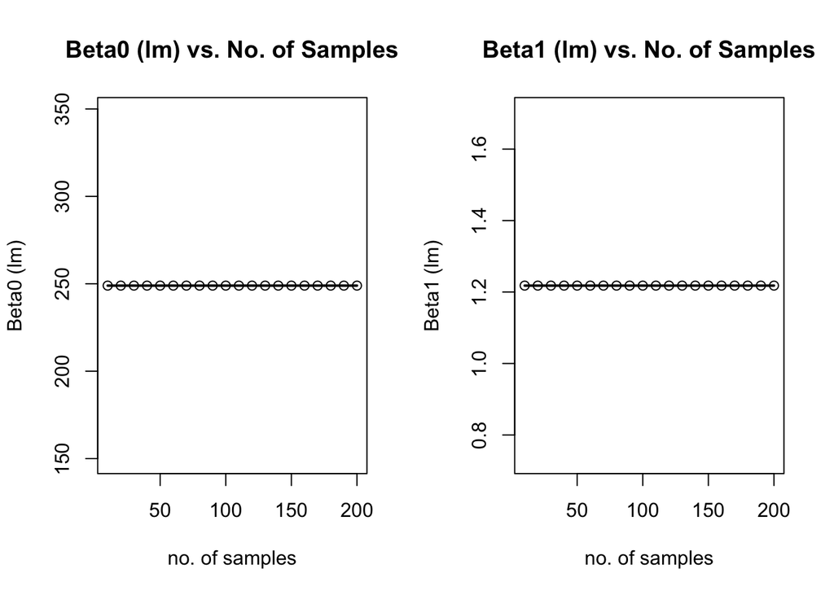

```r
#Plot of lm() based values VS No. of Samples
par(mfrow=c(1,2))
plot(y=plotDf$lm.b0, x=plotDf$num.bootstraps, ylab="Beta0 (lm)", xlab="no. of samples", main="Beta0 (lm) vs. No. of Samples")
xspline(x=plotDf$num.bootstraps, y=plotDf$lm.b0, shape=-0.4, lwd=2)

plot(y=plotDf$lm.b1, x=plotDf$num.bootstraps, ylab="Beta1 (lm)", xlab="no. of samples", main="Beta1 (lm) vs. No. of Samples")
xspline(x=plotDf$num.bootstraps, y=plotDf$lm.b1, shape=-0.4, lwd=2)
```

## Bootstrapped values VS No. of Samples

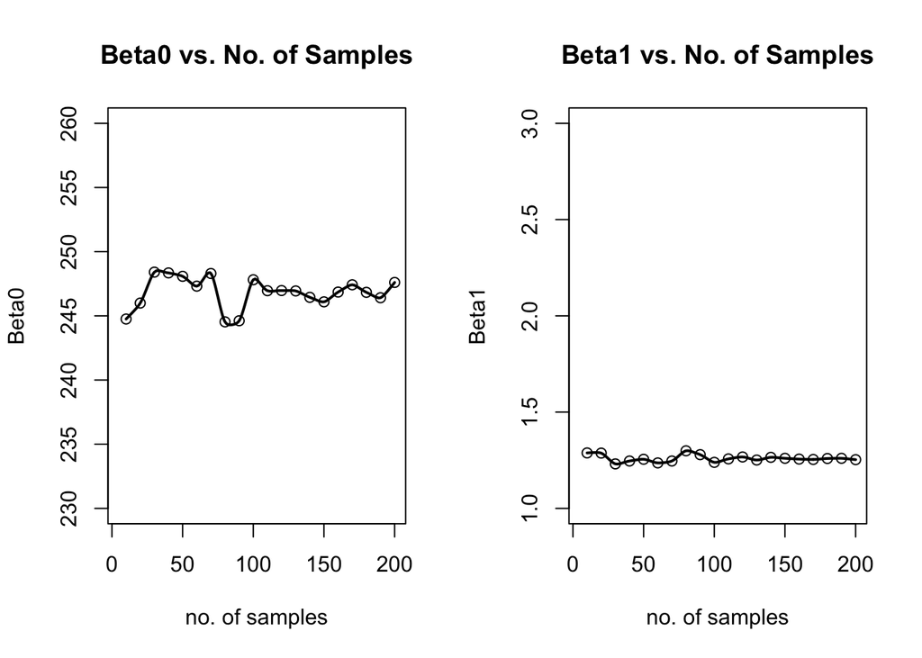

```r
#Beta Coefficient Esimates
par(mfrow=c(1,2))
plot(y=plotDf$bs.b0, x=plotDf$num.bootstraps, ylab="Beta0", xlab="no. of samples", main="Beta0 vs. No. of Samples", ylim=c(230,260), xlim = c(5,200))
xspline(x=plotDf$num.bootstraps, y=plotDf$bs.b0, shape=-0.4, lwd=2)

plot(y=plotDf$bs.b1, x=plotDf$num.bootstraps, ylab="Beta1", xlab="no. of samples", main="Beta1 vs. No. of Samples", ylim=c(1,3), xlim = c(5,200))
xspline(x=plotDf$num.bootstraps, y=plotDf$bs.b1, shape=-0.4, lwd=2)
```

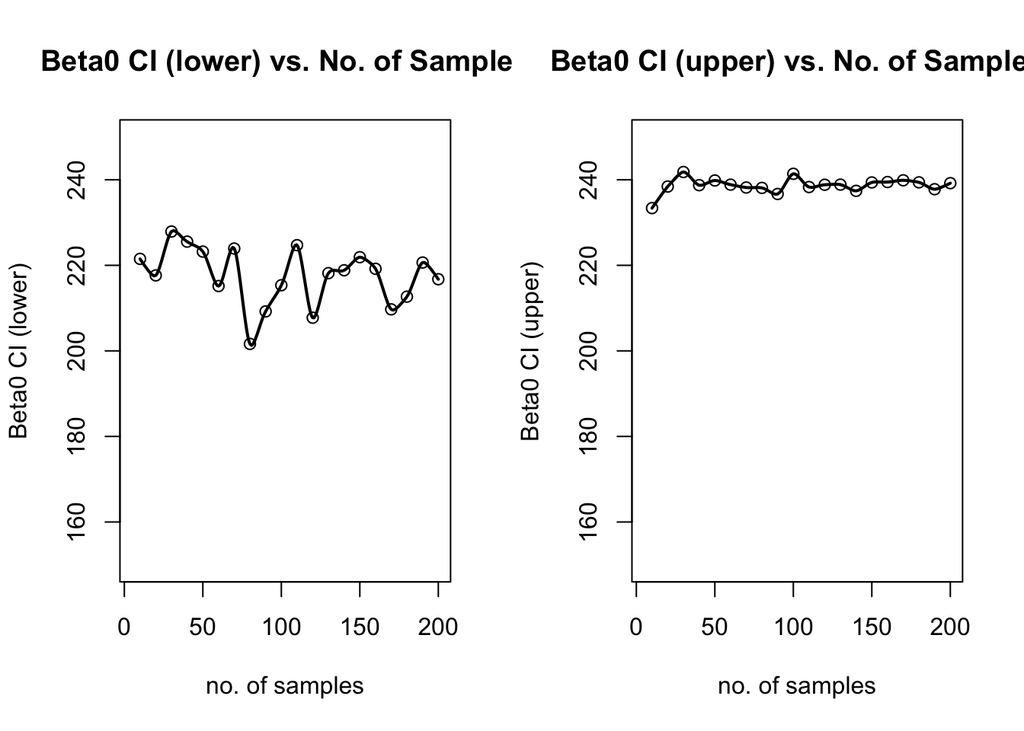

```r
#Confidence Interval Esimates
par(mfrow=c(1,2))
plot(y=plotDf$bs.b0.lwr, x=plotDf$num.bootstraps, ylab="Beta0 CI (lower)", xlab="no. of samples", main="Beta0 CI (lower) vs. No. of Samples", ylim=c(150,250), xlim = c(5,200))
xspline(x=plotDf$num.bootstraps, y=plotDf$bs.b0.lwr, shape=-0.4, lwd=2)

plot(y=plotDf$bs.b0.upr, x=plotDf$num.bootstraps, ylab="Beta0 CI (upper)", xlab="no. of samples", main="Beta0 CI (upper) vs. No. of Samples",ylim=c(150,250), xlim = c(5,200))
xspline(x=plotDf$num.bootstraps, y=plotDf$bs.b0.upr, shape=-0.4, lwd=2)
```

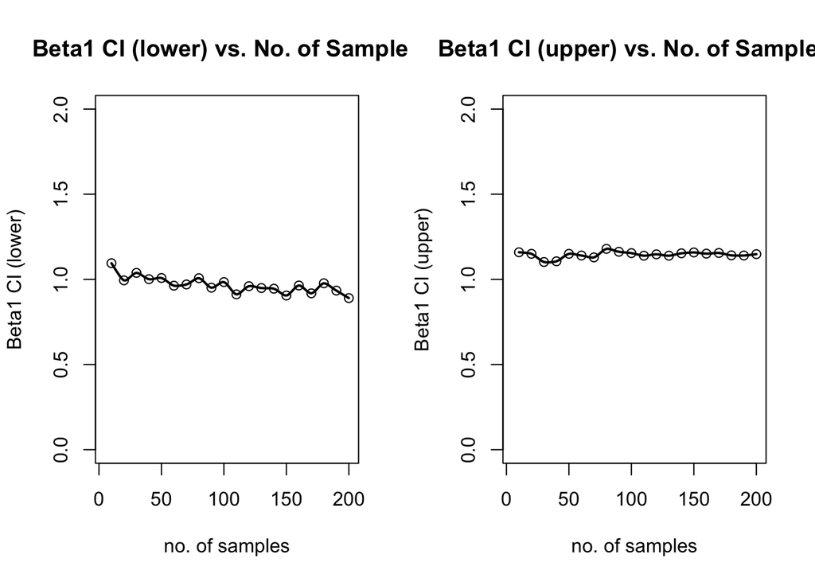

```r
par(mfrow=c(1,2))
plot(y=plotDf$bs.b1.lwr, x=plotDf$num.bootstraps, ylab="Beta1 CI (lower)", xlab="no. of samples", main="Beta1 CI (lower) vs. No. of Samples",ylim=c(0,2), xlim = c(5,200))
xspline(x=plotDf$num.bootstraps, y=plotDf$bs.b1.lwr, shape=-0.4, lwd=2)

plot(y=plotDf$bs.b1.upr, x=plotDf$num.bootstraps, ylab="Beta1 CI (upper)", xlab="no. of samples", main="Beta1 CI (upper) vs. No. of Samples",ylim=c(0,2), xlim = c(5,200))
xspline(x=plotDf$num.bootstraps, y=plotDf$bs.b1.upr, shape=-0.4, lwd=2)
```